# B4 Overpass

Jan-Philipp Kolb

23 Oktober 2018

# Themen dieses Abschnitts

- Die [**Overpass API**](https://wiki.openstreetmap.org/wiki/Overpass_API) von Roland Olbricht wird vorgestellt.
- Die API [**Overpass Turbo**](https://overpass-turbo.eu/)
- Wie man die OSM Daten graphisch darstellen kann.

# Die Overpass API

- Die von Roland Olbricht geschriebene Overpass API ermöglicht es Entwicklern, kleine Auszüge von benutzergenerierten Inhalten von Openstreetmap nach vorgegebenen Kriterien herunterzuladen.
- Overpass ist eine read-only API, die durch den Benutzer ausgewählte Teile der OSM-Daten bereitstellt.
- Overpass kann als eine Datenbank über das Internet verstanden werden.
- Die API eignet sich besonders gut, wenn man nach ganz speziellen Map Features sucht.

# [Overpass Turbo](https://overpass-turbo.eu/)

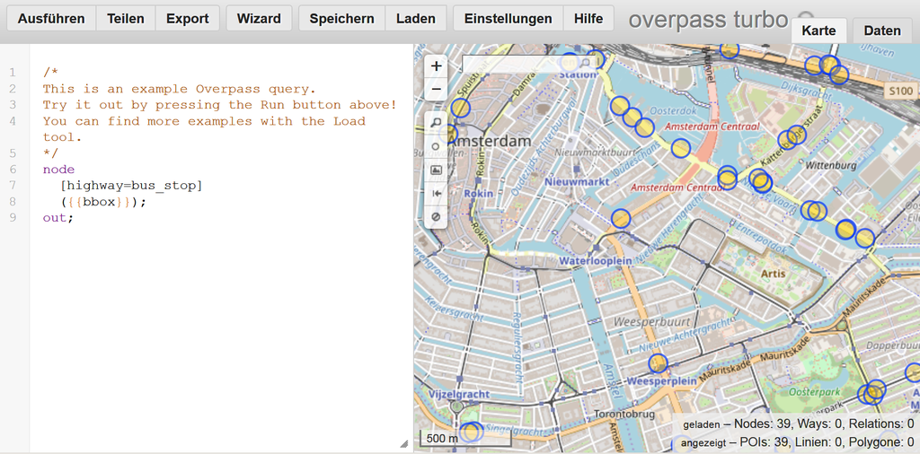

https://overpass-turbo.eu/

# Query Overpass

- In der folgenden Abfrage wird bei Overpass Turbo nach Bars im ausgewählten Fenster gesucht.

```
node
  [amenity=bar]
  ({{bbox}});
out;
```

# Export bei Overpass

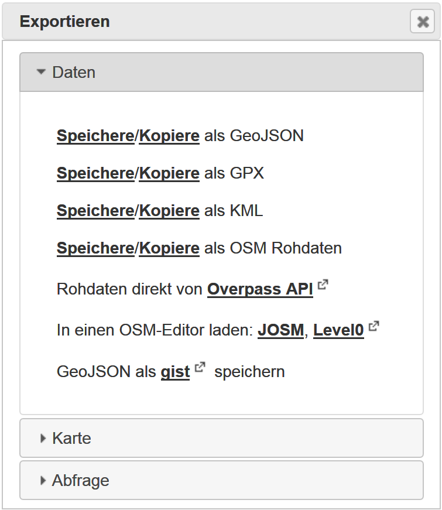